Github:https://tgirmay.github.io/

# Intro to Data Science Fall 2019 Final Project

Project by: Thomas Girmay

Over the years, many people have claimed that the number of violent crimes in the United States has been a result of the increase in violent video games. Over the last couple decades, many news outlets headline articles about a criminal who committed a very violent crime being "obsessed with violent video games" and that being the reason for thier actions. Other studies have been conducted to find see if playing violent video games and violent behavoiours or correlations between the two. This debate has devolved into some groups blaming video games as a whole and not just the violent genres. Though there have been many studies and papers published disproving this thought, many people still beleive a correlation exists. The debate continues to this day and important people such as President Trump blamed video games for a school shooting in 2018. Critics to this debate say that if they are to blame, countries who have a high game-playing population should have a high crime rate. This tutorial aims to see how the number of violent crimes compares with the sales of violent video games. If the rise of these games cause violence, there should be a significant correlation between the two.

I will be using the [Video Game Sales dataset](https://www.kaggle.com/umeshnarayanappa/explore-video-games-sales/data) found on Kaggle and view the data on sales of games of the genre "Shooter", for this is considered by many as the most violent genre because games in this category depict the player or other people doing these violent crimes. I will compare this dataset with the [State Crime](https://think.cs.vt.edu/corgis/csv/state_crime/) Dataset fron the CORGIS Dataset Project. According to a [computational formulas sheet](https://oag.ca.gov/sites/all/files/agweb/pdfs/cjsc/prof10/formulas.pdf) posted by the Office of the Attorney General, "A crime rate is calculated by dividing the number of reported crimes by the total population."

# Crimes Data

First, Lets import the states crimes csv file into a bandas dataset and only select the columns we need: Year, State, and all of the violent crime rates. Then, lets calculate the total number of crimes per year in each category and store this data in a new dataframe.

```python
import pandas as pd
import glob
import numpy as np
from scipy import stats
import matplotlib.pyplot as plt

crimesDf =  pd.read_csv(".\state_crime.csv")
crimesDf = crimesDf[["Year",
                     "State",
                     "Data.Rates.Violent.All",
                     "Data.Rates.Violent.Assault",
                     "Data.Rates.Violent.Murder",
                     "Data.Rates.Violent.Rape",
                     "Data.Rates.Violent.Robbery"
                    ]]


#Grab the unique years and store them
years = crimesDf["Year"].unique()

violentCrimePerYear = {}
assaultPerYear = {}
murderPerYear = {}
rapePerYear = {}
robberyPerYear = {}

#initialize all values for the years in the dict to 0
for year in years:
    violentCrimePerYear[year] = 0
    assaultPerYear[year] = 0
    murderPerYear[year] = 0
    rapePerYear[year] = 0
    robberyPerYear[year] = 0

#for each year, iterate through the dataset and add the number of violent crimes per state to the count for the year
for year in years:
    for index, row in crimesDf.iterrows():
        if row["Year"] == year:
            assaultPerYear[year] += row["Data.Rates.Violent.Assault"]
            murderPerYear[year] += row["Data.Rates.Violent.Murder"]
            rapePerYear[year] += row["Data.Rates.Violent.Rape"]
            robberyPerYear[year] += row["Data.Rates.Violent.Robbery"]
            violentCrimePerYear[year] += row["Data.Rates.Violent.All"]
display(crimesDf.head())
crimesDf.dtypes
```

|  | Year | State | Data.Rates.Violent.All | Data.Rates.Violent.Assault | Data.Rates.Violent.Murder | Data.Rates.Violent.Rape | Data.Rates.Violent.Robbery |
| --- | --- | --- | --- | --- | --- | --- | --- |
| 0 | 1960 | Alabama | 186.6 | 138.1 | 12.4 | 8.6 | 27.5 |
| 1 | 1961 | Alabama | 168.5 | 128.9 | 12.9 | 7.6 | 19.1 |
| 2 | 1962 | Alabama | 157.3 | 119.0 | 9.4 | 6.5 | 22.5 |
| 3 | 1963 | Alabama | 182.7 | 142.1 | 10.2 | 5.7 | 24.7 |
| 4 | 1964 | Alabama | 213.1 | 163.0 | 9.3 | 11.7 | 29.1 |

```
Year                            int64
State                          object
Data.Rates.Violent.All        float64
Data.Rates.Violent.Assault    float64
Data.Rates.Violent.Murder     float64
Data.Rates.Violent.Rape       float64
Data.Rates.Violent.Robbery    float64
dtype: object
```

```python
assaultOverYearsDf = pd.Series(assaultPerYear, name ='Total_Assault_Rate').to_frame()
murderOverYearsDf = pd.Series(murderPerYear, name ='Total_Murder_Rate').to_frame()
rapeOverYearsDf = pd.Series(rapePerYear, name ='Total_Rape_Rate').to_frame()
robberyOverYearsDf = pd.Series(robberyPerYear, name ='Total_Robbery_Rate').to_frame()
violentOverYearsDf = pd.Series(violentCrimePerYear, name ='Total_Violent_Crime_Rate').to_frame()

dfs= [assaultOverYearsDf, murderOverYearsDf, rapeOverYearsDf, robberyOverYearsDf,violentOverYearsDf]
for df in dfs:
    df.index.name = "Year"

#this lambda merges all of the dataframes in the list dfs on year.
#now we have all of the data in one df

crimesOverYearsDf =pd.merge(violentOverYearsDf,assaultOverYearsDf,on="Year")
crimesOverYearsDf = pd.merge(crimesOverYearsDf,murderOverYearsDf,on="Year")
crimesOverYearsDf = pd.merge(crimesOverYearsDf,rapeOverYearsDf,on="Year")
crimesOverYearsDf = pd.merge(crimesOverYearsDf,robberyOverYearsDf,on="Year")

crimesOverYearsDf.head()
```

| Year | Total_Violent_Crime_Rate | Total_Assault_Rate | Total_Murder_Rate | Total_Rape_Rate | Total_Robbery_Rate |
| --- | --- | --- | --- | --- | --- |
| 1960 | 5904.2 | 3265.4 | 266.4 | 411.8 | 1960.7 |
| 1961 | 5802.6 | 3204.6 | 245.1 | 393.3 | 1959.4 |
| 1962 | 5889.9 | 3266.2 | 229.7 | 404.5 | 1990.1 |
| 1963 | 6212.3 | 3477.5 | 232.2 | 402.0 | 2100.4 |
| 1964 | 7552.7 | 4504.7 | 244.3 | 496.7 | 2307.7 |

First, lets take a look at how the total number of violent crimes changed over the years.

```
Total_Violent_Crime_Rate    float64
Total_Assault_Rate          float64
Total_Murder_Rate           float64
Total_Rape_Rate             float64
Total_Robbery_Rate          float64
dtype: object
```

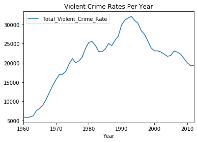

```python
crimesOverYearsDf.plot.line(y='Total_Violent_Crime_Rate', title = "Violent Crime Rates Per Year")
crimesOverYearsDf.dtypes
```

The total crime rate per year has risen since 1960 and is now on a downward trend since around 1993. Lets now plot all of the crime rates to see how each category changed. If this same trend is seen with all of the subcategories of violent crime, then this is a useful representation for later comparisons.

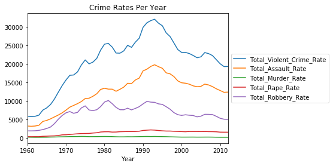

```python
crimesOverYearsDf.plot.line( title = "Crime Rates Per Year")
plt.legend(loc='center left', bbox_to_anchor=(1.0, 0.5))
```

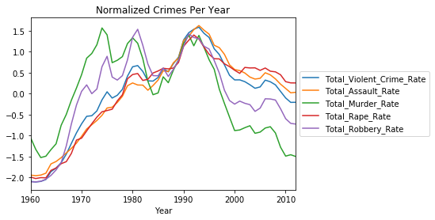

```python
normalizedCrimeDf = (crimesOverYearsDf -crimesOverYearsDf.mean())/crimesOverYearsDf.std()
normalizedCrimeDf.plot.line(title = "Normalized Crimes Per Year")
plt.legend(loc='center left', bbox_to_anchor=(1.0, 0.5))
```

# Games Data

Like before, Let's edit our dataframe to only include the data we need. Lets grab the Sales, Genre, and Year columns and total the sales by year.

```python
gamesDf = pd.read_csv(".\gamesales.csv")
genres = gamesDf["Genre"].unique()
years = gamesDf["Year"].unique().astype(int)

salesPerGenreOverYears = {}
display(genres)
for genre in genres:
    for year in years:
        salesPerGenreOverYears[year,genre] = 0

for index, row in gamesDf.iterrows():
    if((row["Year"] in years) & (row["Genre"] in genres)):
        salesPerGenreOverYears[row["Year"],row["Genre"]] += row["NA_Sales"]
#Sales are in Millions
```

```
array(['Sports', 'Platform', 'Racing', 'Role-Playing', 'Puzzle', 'Misc',
       'Shooter', 'Simulation', 'Action', 'Fighting', 'Adventure',
       'Strategy'], dtype=object)
```

Now that we have calculated the number of sales by year and genre, let us look at our current dataframe.

```python
#store data set by genre in df
genreSalesDf = pd.Series(salesPerGenreOverYears, name ='Sales').to_frame()
genreSalesDf.head()
```

|  |  | Sales |
| --- | --- | --- |
| 2006 | Sports | 72.91 |
| 1985 | Sports | 0.18 |
| 2008 | Sports | 48.92 |
| 2009 | Sports | 71.47 |
| 1996 | Sports | 7.78 |

Since our dictionary had two keys, the resulting dataframe has two indices. To make the processing easier, lets get rid of this by reseting our index and add some column names.

```python
#remove the double indexing
genreSalesDf.reset_index(level = 0, inplace = True )
genreSalesDf.reset_index(level = 0, inplace = True )
genreSalesDf.columns = ["Genre", "Year", "Sales_in_Millions"]
genreSalesDf.head()
```

|  | Genre | Year | Sales_in_Millions |
| --- | --- | --- | --- |
| 0 | Sports | 2006 | 72.91 |
| 1 | Sports | 1985 | 0.18 |
| 2 | Sports | 2008 | 48.92 |
| 3 | Sports | 2009 | 71.47 |
| 4 | Sports | 1996 | 7.78 |

Now we can calculate the number of sales of the more violent genres over the years in a similar manner as we did with the violent crimes.

```python
shooterSalesDf = pd.DataFrame()
actionSalesDf = pd.DataFrame()
fightingSalesDf = pd.DataFrame()

shooterYear = []
actionYear = []
fightingYear = []

shooterSales = []
actionSales = []
fightingSales = []

for index, row in genreSalesDf.iterrows():
    if(row["Genre"]=="Shooter"):
        shooterYear.append(row["Year"])
        shooterSales.append(row["Sales_in_Millions"])
    elif(row["Genre"]=="Action"):
        actionYear.append(row["Year"])
        actionSales.append(row["Sales_in_Millions"])
    elif(row["Genre"]=="Fighting"):
        fightingYear.append(row["Year"])
        fightingSales.append(row["Sales_in_Millions"])

shooterSalesDf["Year"] = shooterYear
shooterSalesDf["Shooter_Sales_in_Millions"] = shooterSales
shooterSalesDf =shooterSalesDf.set_index("Year").sort_index()

actionSalesDf["Year"] =actionYear
actionSalesDf["Action_Sales_in_Millions"] = actionSales
actionSalesDf =actionSalesDf.set_index("Year").sort_index()

fightingSalesDf["Year"] =fightingYear
fightingSalesDf["Fighting_Sales_in_Millions"] = fightingSales
fightingSalesDf =fightingSalesDf.set_index("Year").sort_index()

gameSalesDf = pd.merge(pd.merge(shooterSalesDf,actionSalesDf,on="Year"),fightingSalesDf, on='Year')
gameSalesDf.drop(-2147483648 , inplace = True)
display(gameSalesDf.head())

gameSalesDf.dtypes
```

| Year | Shooter_Sales_in_Millions | Action_Sales_in_Millions | Fighting_Sales_in_Millions |
| --- | --- | --- | --- |
| 1980 | 6.56 | 0.32 | 0.72 |
| 1981 | 9.37 | 13.86 | 0.00 |
| 1982 | 3.55 | 6.07 | 0.00 |
| 1983 | 0.45 | 2.67 | 0.00 |
| 1984 | 27.79 | 0.80 | 0.00 |

```
Shooter_Sales_in_Millions     float64
Action_Sales_in_Millions      float64
Fighting_Sales_in_Millions    float64
dtype: object
```

We have our games dataframe now with the correct data types and heading names. For every year, we can see each genre's game sale values. We can set up a line plot to see the game sale trends as we did with the crimes data.

# Analysis

Let's look at both of the plots and see what we have so far We also need to constrict our plot to only include ranges that exist in both frames.

```
(1980, 2010)
```

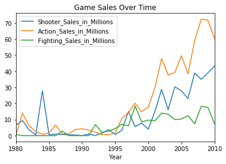

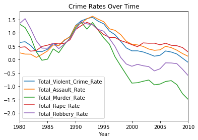

```python
ax=gameSalesDf.plot.line(title ="Game Sales Over Time" )
ax.set_xlim(1980,2010)

ay = normalizedCrimeDf.plot.line(title ="Crime Rates Over Time")
ay.set_xlim(1980,2010)
```

So that we can compare these values, lets normalize both data sets and plot them on the same graph

| Year | Shooter_Sales | Action_Sales | Fighting_Sales | Total_Violent_Crime_Rate |
| --- | --- | --- | --- | --- |
| 1980 | -0.530696 | -0.933301 | -0.867353 | 0.642370 |
| 1981 | -0.348562 | -0.353026 | -0.993769 | 0.671113 |
| 1982 | -0.725793 | -0.686877 | -0.993769 | 0.532044 |
| 1983 | -0.926724 | -0.832589 | -0.993769 | 0.306336 |
| 1984 | 0.845355 | -0.912730 | -0.993769 | 0.299984 |

```
Shooter_Sales               float64
Action_Sales                float64
Fighting_Sales              float64
Total_Violent_Crime_Rate    float64
dtype: object
```

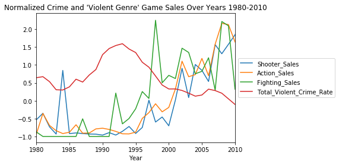

```python
normalizedGameSalessDf = (gameSalesDf -gameSalesDf.mean())/gameSalesDf.std()
normalizedGameSalessDf.columns = ["Shooter_Sales", "Action_Sales", "Fighting_Sales"]
combinedNormalizedStatsDf = normalizedGameSalessDf
combinedNormalizedStatsDf["Total_Violent_Crime_Rate"] = normalizedCrimeDf["Total_Violent_Crime_Rate"]
display(combinedNormalizedStatsDf.head())
display(combinedNormalizedStatsDf.dtypes)
ax=combinedNormalizedStatsDf.plot.line()
ax.set_xlim(1980,2010)
ax.set_title("Normalized Crime and 'Violent Genre' Game Sales Over Years 1980-2010")

plt.legend(loc='center left', bbox_to_anchor=(1.0, 0.5))
```

We can see that all of the selected game genres are on an upward trend while the crime rates are dropping. To more closely observe their trends in relation to eachother, we can set up a scatterplot of the total violent crime rate over the rate of sales of these games.

```python
combinedNormalizedStatsDf =combinedNormalizedStatsDf.reset_index()
```

```
p Value = 1.2322415954973911e-06
r Value = -0.7329335260479979
```

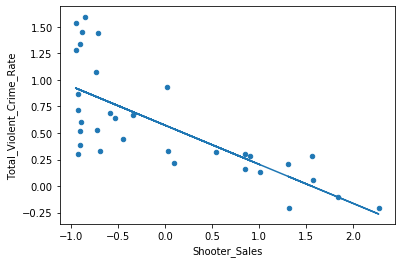

```python
combinedNormalizedStatsDf=combinedNormalizedStatsDf[combinedNormalizedStatsDf["Year"]<2013]
combinedNormalizedStatsDf.set_index("Year")
slope, intercept, r_value, p_value, std_err = stats.linregress(combinedNormalizedStatsDf["Shooter_Sales"],combinedNormalizedStatsDf["Total_Violent_Crime_Rate"])
line = slope*combinedNormalizedStatsDf["Shooter_Sales"]+intercept
combinedNormalizedStatsDf.plot.scatter(x="Shooter_Sales", y="Total_Violent_Crime_Rate")

plt.plot(combinedNormalizedStatsDf["Shooter_Sales"], line)



print("p Value =", p_value)
print("r Value =", r_value)
```

```
p Value = 4.666268751564205e-06
r Value = -0.7048502765647119
```

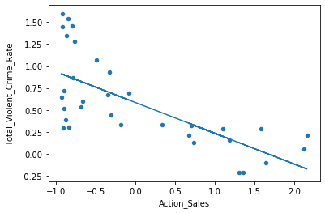

```python
slope, intercept, r_value, p_value, std_err = stats.linregress(combinedNormalizedStatsDf["Action_Sales"],combinedNormalizedStatsDf["Total_Violent_Crime_Rate"])
line = slope*combinedNormalizedStatsDf["Action_Sales"]+intercept
combinedNormalizedStatsDf.plot.scatter(x="Action_Sales", y="Total_Violent_Crime_Rate")

plt.plot(combinedNormalizedStatsDf["Action_Sales"], line)



print("p Value =", p_value)
print("r Value =", r_value)
```

```
p Value = 0.013690003791766851
r Value = -0.4249749908387816
```

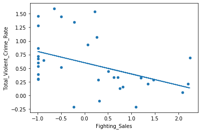

```python
slope, intercept, r_value, p_value, std_err = stats.linregress(combinedNormalizedStatsDf["Fighting_Sales"],combinedNormalizedStatsDf["Total_Violent_Crime_Rate"])
line = slope*combinedNormalizedStatsDf["Fighting_Sales"]+intercept
combinedNormalizedStatsDf.plot.scatter(x="Fighting_Sales", y="Total_Violent_Crime_Rate")

plt.plot(combinedNormalizedStatsDf["Fighting_Sales"], line)



print("p Value =", p_value)
print("r Value =", r_value)
```

# Conclusion

From the scatterplots above, we can see that there is a relatively high negative correlation between the total violent crime rate and both shooters and action games, and that the correlation with fighting games, while low, is also negative. Furthermore, the p values for the correlations with shooters and action games are very low so for a hypothesis test, we can reject the null hypothesis.

This does not mean that video games reduce violence for correlation does not cause causation; however, for video games to be the cause violence, there needs to be a positive correaltion between the sales and crime rate. Since we did not see this trend in the data, we can say that video games are not to blame for violent crimes. This debate needs to be put to rest so that we can focus on finding real causes of violence so we can reduce our crime rates further.